# MA_Hw_06_03

## Packages

```r
suppressMessages(library(plyr))
suppressMessages(library(rethinking))
suppressMessages(library(rstan))
suppressMessages(library(tidyverse))
suppressMessages(library(ggplot2))
suppressMessages(library(gridExtra))
suppressMessages(library(skimr)) # for n_unique func
```

## Data-processing

### Read data

```r
data(bangladesh)
bangladesh
```

| woman | district | use.contraception | living.children | age.centered | urban |
| --- | --- | --- | --- | --- | --- |
| 1 | 1 | 0 | 4 | 18.4400 | 1 |
| 2 | 1 | 0 | 1 | -5.5599 | 1 |
| 3 | 1 | 0 | 3 | 1.4400 | 1 |
| 4 | 1 | 0 | 4 | 8.4400 | 1 |
| 5 | 1 | 0 | 1 | -13.5590 | 1 |
| 6 | 1 | 0 | 1 | -11.5600 | 1 |
| 7 | 1 | 0 | 4 | 18.4400 | 1 |
| 8 | 1 | 0 | 4 | -3.5599 | 1 |
| 9 | 1 | 0 | 2 | -5.5599 | 1 |
| 10 | 1 | 0 | 4 | 1.4400 | 1 |

[output cut: 1924 more lines]

### Select data

I select the data which might be used first

```r
train = bangladesh %>%
  dplyr::select("district", "urban", "use.contraception")

train$district = as.integer(as.factor(train$district))
train
```

| district | urban | use.contraception |
| --- | --- | --- |
| 1 | 1 | 0 |
| 1 | 1 | 0 |
| 1 | 1 | 0 |
| 1 | 1 | 0 |
| 1 | 1 | 0 |
| 1 | 1 | 0 |
| 1 | 1 | 0 |
| 1 | 1 | 0 |
| 1 | 1 | 0 |
| 1 | 1 | 0 |

[output cut: 1924 more lines]

## PART A

### Centered Model

Centered varying model

```r
q3_model_A = "
data{
  int N;
    int N_district;

    int district[N];
    int urban[N];

    int contracept[N]; // y
}
parameters {
    // parameters
    vector[2] alpha[N_district]; // N_district x 2 matrix

    // hyperparameters
    vector<lower=0>[2] sigma_alpha;
    corr_matrix[2] rho_alpha;

}
transformed parameters {
    vector[N] p;
    matrix[2,2] SIGMA_alpha; //sigma matrix in MVN

    for (i in 1:N){
        p[i] = inv_logit( alpha[district[i], 1] + alpha[district[i], 2] * urban[i] );
    }

    SIGMA_alpha = quad_form_diag(rho_alpha, sigma_alpha);

}
model{
    //likelihood
    contracept ~ binomial(1, p);

    //prior
    alpha ~ multi_normal(rep_vector(0, 2), SIGMA_alpha);

    //hyper prior
    sigma_alpha ~ exponential(1);
    rho_alpha ~ lkj_corr(2);

}
generated quantities {
    vector[N] log_lik;
    vector[N] pred_y;
    for (i in 1:N){
        log_lik[i] = binomial_lpmf(contracept[i] | 1, p[i]);
    }
    for (i in 1:N){
        pred_y[i] = binomial_rng(1, p[i]);
    }
}
"
```

#### Data and Initialise

```r
q3_data_A = list(
  N = nrow(train),
    N_district = length(unique(train$district)),

    district = train$district,
    urban = train$urban,
    contracept = train$use.contraception
)
```

#### Fit

```r
q3_fit_A = stan(
                model_code = q3_model_A,
                data = q3_data_A,
                cores = 4, chains = 2,
                warmup = 4000, iter = 16000,
                control = list(adapt_delta=.99)
                )
```

```
recompiling to avoid crashing R session
```

```
starting worker pid=9119 on localhost:11482 at 20:37:40.157
starting worker pid=9133 on localhost:11482 at 20:37:40.407
```

```
There were 1 transitions after warmup that exceeded the maximum treedepth. Increase max_treedepth above 10. See
http://mc-stan.org/misc/warnings.html#maximum-treedepth-exceededExamine the pairs() plot to diagnose sampling problems
```

### Check the posteriors

we can see that all the R hat of paras are 1, which means they are convergent

```r
options(max.print=1000000)
print(q3_fit_A, pars = c("alpha"))
```

```
Inference for Stan model: 8ef9b7fcf2106ce3426ad9fcbbfdfe11.
2 chains, each with iter=16000; warmup=4000; thin=1;
post-warmup draws per chain=12000, total post-warmup draws=24000.

             mean se_mean   sd  2.5%   25%   50%   75% 97.5% n_eff Rhat
alpha[1,1]  -1.64    0.00 0.35 -2.35 -1.87 -1.63 -1.39 -0.98 26199    1
alpha[1,2]   1.17    0.00 0.42  0.37  0.88  1.17  1.46  2.01 24489    1
alpha[2,1]  -0.51    0.00 0.42 -1.35 -0.79 -0.50 -0.22  0.29 32840    1
alpha[2,2]   0.52    0.00 0.76 -0.96  0.02  0.50  1.00  2.04 27302    1
alpha[3,1]   0.00    0.01 0.94 -1.85 -0.63 -0.01  0.61  1.87 25789    1
alpha[3,2]   0.34    0.01 1.12 -1.83 -0.40  0.31  1.05  2.65 25078    1
alpha[4,1]  -0.82    0.00 0.46 -1.75 -1.11 -0.80 -0.51  0.03 26631    1
alpha[4,2]   1.66    0.01 0.71  0.36  1.18  1.63  2.11  3.15 14968    1
alpha[5,1]  -0.55    0.00 0.32 -1.20 -0.76 -0.54 -0.33  0.07 32958    1
alpha[5,2]   0.55    0.00 0.66 -0.73  0.13  0.55  0.97  1.87 29775    1
alpha[6,1]  -1.05    0.00 0.29 -1.63 -1.24 -1.04 -0.85 -0.50 33298    1
alpha[6,2]   1.38    0.00 0.59  0.29  0.98  1.36  1.76  2.61 22528    1
alpha[7,1]  -0.75    0.00 0.45 -1.68 -1.05 -0.74 -0.45  0.11 31213    1
alpha[7,2]   0.76    0.00 0.79 -0.76  0.24  0.74  1.26  2.37 27384    1
alpha[8,1]  -0.58    0.00 0.33 -1.25 -0.80 -0.57 -0.36  0.06 32673    1
alpha[8,2]   0.90    0.00 0.68 -0.36  0.44  0.87  1.32  2.32 22766    1
alpha[9,1]  -0.87    0.00 0.44 -1.78 -1.16 -0.86 -0.57 -0.03 28386    1
alpha[9,2]   1.02    0.00 0.72 -0.33  0.54  1.00  1.49  2.50 25579    1
alpha[10,1] -1.43    0.00 0.59 -2.67 -1.81 -1.40 -1.03 -0.37 29155    1
alpha[10,2]  1.45    0.01 0.91 -0.22  0.85  1.41  2.02  3.37 21157    1
alpha[11,1] -2.12    0.00 0.60 -3.41 -2.49 -2.08 -1.70 -1.06 23767    1
alpha[11,2]  2.14    0.01 0.97  0.39  1.48  2.09  2.74  4.20 15893    1
alpha[12,1] -0.53    0.00 0.40 -1.32 -0.79 -0.52 -0.26  0.24 33122    1
alpha[12,2]  0.30    0.00 0.64 -0.96 -0.12  0.30  0.72  1.56 29626    1
alpha[13,1] -0.19    0.00 0.45 -1.09 -0.49 -0.19  0.11  0.67 30709    1
alpha[13,2] -0.02    0.00 0.65 -1.31 -0.45 -0.02  0.42  1.24 28864    1
alpha[14,1] -0.48    0.00 0.45 -1.39 -0.78 -0.47 -0.17  0.39 23018    1
alpha[14,2]  1.12    0.00 0.50  0.16  0.78  1.11  1.45  2.12 22876    1
alpha[15,1] -0.45    0.00 0.48 -1.41 -0.77 -0.44 -0.12  0.48 29543    1
alpha[15,2]  0.24    0.00 0.67 -1.09 -0.21  0.25  0.69  1.56 27494    1
alpha[16,1]  0.00    0.00 0.42 -0.82 -0.29  0.00  0.28  0.82 30756    1
alpha[16,2]  0.32    0.00 0.72 -1.03 -0.17  0.29  0.78  1.79 24050    1
alpha[17,1] -0.74    0.00 0.40 -1.56 -1.01 -0.73 -0.47  0.02 33121    1
alpha[17,2]  0.75    0.00 0.76 -0.70  0.25  0.73  1.23  2.32 26262    1
alpha[18,1] -0.85    0.00 0.35 -1.56 -1.08 -0.84 -0.61 -0.18 31714    1
```

[output cut: 75 more lines]

```
alpha[56,1] -1.21    0.00 0.45 -2.15 -1.51 -1.20 -0.91 -0.37 30840    1
alpha[56,2]  0.95    0.00 0.72 -0.43  0.48  0.94  1.42  2.38 22720    1
alpha[57,1]  0.17    0.00 0.42 -0.65 -0.11  0.16  0.44  0.99 28137    1
alpha[57,2] -0.58    0.00 0.60 -1.80 -0.98 -0.56 -0.17  0.56 23327    1
alpha[58,1] -1.22    0.00 0.61 -2.49 -1.61 -1.20 -0.81 -0.10 29349    1
alpha[58,2]  1.24    0.01 0.91 -0.45  0.62  1.20  1.82  3.13 21096    1
alpha[59,1] -1.16    0.00 0.45 -2.07 -1.45 -1.15 -0.85 -0.32 27742    1
alpha[59,2]  0.78    0.00 0.64 -0.47  0.35  0.78  1.21  2.04 24081    1
alpha[60,1] -1.18    0.00 0.40 -1.99 -1.44 -1.17 -0.91 -0.43 30384    1
alpha[60,2]  0.73    0.00 0.61 -0.46  0.33  0.73  1.14  1.92 21685    1

Samples were drawn using NUTS(diag_e) at Sun Jun 21 20:56:12 2020.
For each parameter, n_eff is a crude measure of effective sample size,
and Rhat is the potential scale reduction factor on split chains (at
convergence, Rhat=1).
```

## PART B

### Un-Centered Model

To decompose the Cov, I use the L_Rho and Z_alpha to replace the original R and diag_matrix(sigma_par)

```r
q3_model_B = "
data{
  int N;
    int N_district;

    int district[N];
    int urban[N];

    int contracept[N]; // y
}
parameters {
    //hyperparameters
    cholesky_factor_corr[2] L_Rho_alpha;
    vector<lower=0>[2] sigma_alpha;

    //parameters
    matrix[2, N_district] z_alpha;
}

transformed parameters{
    vector[N] p;
    matrix[N_district, 2] alpha;

    // calculate alpha
    alpha = (diag_pre_multiply(sigma_alpha, L_Rho_alpha) * z_alpha)';
    // we transpose the result to make it a N_district x 2 matrix


    // calculate p **you have to put this part after the parts calculating alpha/beta**
    for (i in 1:N){
        p[i] = inv_logit(alpha[district[i], 1] + alpha[district[i], 2] * urban[i]);
    }

}
model{
    //likelihood
    contracept ~ binomial(1, p);

    //hyperprior
    L_Rho_alpha ~ lkj_corr_cholesky(2);
    sigma_alpha ~ exponential(1);

    //prior
    to_vector(z_alpha) ~ normal(0, 1);

}
generated quantities{
    vector[N] log_lik;
    vector[N] pred_y;
    for (i in 1:N){
        log_lik[i] = binomial_lpmf(contracept[i] | 1, p[i]);
    }
    for (i in 1:N){
        pred_y[i] = binomial_rng(1, p[i]);
    }
}
"
```

#### Data and Initialise

```r
q3_data_B = list(
  N = nrow(train),
    N_district = length(unique(train$district)),

    district = train$district,
    urban = train$urban,
    contracept = train$use.contraception
)
```

#### Fit

```r
q3_fit_B = stan(
    model_code = q3_model_B,
    data = q3_data_B,
    cores = 4, chains = 2,
    warmup = 4000, iter = 16000,
    control = list(adapt_delta=.99, max_treedepth = 25)
    )
```

```
starting worker pid=9365 on localhost:11482 at 21:02:42.971
starting worker pid=9379 on localhost:11482 at 21:02:43.234
```

### Check the posteriors

we can see that all the R hat of paras are 1, which means they are convergent

```r
options(max.print=1000000)
print(q3_fit_B, pars = c("alpha"))
```

```
Inference for Stan model: 3923b0fb5df7f19926d96d30028fc3d6.
2 chains, each with iter=16000; warmup=4000; thin=1;
post-warmup draws per chain=12000, total post-warmup draws=24000.

             mean se_mean   sd  2.5%   25%   50%   75% 97.5% n_eff Rhat
alpha[1,1]  -1.63    0.00 0.35 -2.34 -1.86 -1.62 -1.39 -0.98 33321    1
alpha[1,2]   1.18    0.00 0.42  0.37  0.89  1.17  1.45  2.02 35258    1
alpha[2,1]  -0.51    0.00 0.42 -1.35 -0.79 -0.50 -0.23  0.30 34876    1
alpha[2,2]   0.51    0.00 0.76 -0.97  0.01  0.50  1.00  2.04 30736    1
alpha[3,1]  -0.01    0.01 0.95 -1.89 -0.63 -0.01  0.62  1.85 26777    1
alpha[3,2]   0.34    0.01 1.12 -1.82 -0.40  0.30  1.05  2.65 27414    1
alpha[4,1]  -0.81    0.00 0.46 -1.75 -1.11 -0.80 -0.50  0.05 26785    1
alpha[4,2]   1.66    0.00 0.71  0.37  1.16  1.62  2.11  3.13 20670    1
alpha[5,1]  -0.55    0.00 0.32 -1.20 -0.76 -0.54 -0.33  0.07 30902    1
alpha[5,2]   0.56    0.00 0.66 -0.75  0.12  0.55  0.99  1.88 29624    1
alpha[6,1]  -1.05    0.00 0.29 -1.64 -1.24 -1.04 -0.85 -0.50 37441    1
alpha[6,2]   1.38    0.00 0.59  0.28  0.98  1.37  1.76  2.57 28237    1
alpha[7,1]  -0.76    0.00 0.45 -1.68 -1.05 -0.75 -0.45  0.10 32057    1
alpha[7,2]   0.76    0.00 0.79 -0.76  0.24  0.75  1.26  2.37 26618    1
alpha[8,1]  -0.58    0.00 0.34 -1.26 -0.81 -0.58 -0.35  0.06 30738    1
alpha[8,2]   0.90    0.00 0.69 -0.38  0.44  0.88  1.34  2.34 24707    1
alpha[9,1]  -0.87    0.00 0.43 -1.75 -1.16 -0.86 -0.57 -0.04 28315    1
alpha[9,2]   1.02    0.00 0.71 -0.32  0.54  1.00  1.48  2.48 25711    1
alpha[10,1] -1.44    0.00 0.59 -2.68 -1.81 -1.40 -1.03 -0.36 26180    1
alpha[10,2]  1.45    0.01 0.91 -0.23  0.84  1.41  2.02  3.34 22663    1
alpha[11,1] -2.12    0.00 0.60 -3.40 -2.50 -2.08 -1.70 -1.07 22660    1
alpha[11,2]  2.14    0.01 0.96  0.39  1.48  2.09  2.73  4.16 17990    1
alpha[12,1] -0.52    0.00 0.39 -1.32 -0.78 -0.52 -0.26  0.23 29536    1
alpha[12,2]  0.29    0.00 0.63 -0.97 -0.12  0.30  0.71  1.53 29144    1
alpha[13,1] -0.20    0.00 0.45 -1.10 -0.50 -0.20  0.10  0.67 31458    1
alpha[13,2] -0.01    0.00 0.65 -1.29 -0.44 -0.01  0.42  1.25 30030    1
alpha[14,1] -0.47    0.00 0.45 -1.38 -0.77 -0.47 -0.17  0.39 25499    1
alpha[14,2]  1.11    0.00 0.50  0.16  0.77  1.10  1.45  2.11 27429    1
alpha[15,1] -0.44    0.00 0.48 -1.40 -0.77 -0.43 -0.12  0.49 28547    1
alpha[15,2]  0.23    0.00 0.67 -1.08 -0.22  0.23  0.67  1.56 28462    1
alpha[16,1]  0.00    0.00 0.42 -0.83 -0.28  0.00  0.29  0.83 28584    1
alpha[16,2]  0.32    0.00 0.72 -1.04 -0.16  0.30  0.76  1.79 27786    1
alpha[17,1] -0.74    0.00 0.40 -1.55 -1.00 -0.73 -0.46  0.03 28859    1
alpha[17,2]  0.74    0.00 0.76 -0.72  0.24  0.73  1.23  2.25 27294    1
alpha[18,1] -0.85    0.00 0.36 -1.58 -1.08 -0.84 -0.61 -0.17 30469    1
```

[output cut: 75 more lines]

```
alpha[56,1] -1.21    0.00 0.45 -2.13 -1.50 -1.20 -0.91 -0.38 29915    1
alpha[56,2]  0.95    0.00 0.71 -0.43  0.48  0.94  1.41  2.35 27948    1
alpha[57,1]  0.17    0.00 0.41 -0.64 -0.11  0.16  0.44  0.99 28653    1
alpha[57,2] -0.58    0.00 0.59 -1.78 -0.98 -0.57 -0.18  0.55 29059    1
alpha[58,1] -1.22    0.00 0.61 -2.51 -1.61 -1.19 -0.81 -0.10 25648    1
alpha[58,2]  1.24    0.01 0.91 -0.44  0.63  1.19  1.81  3.15 22485    1
alpha[59,1] -1.16    0.00 0.45 -2.07 -1.45 -1.15 -0.86 -0.33 30649    1
alpha[59,2]  0.78    0.00 0.64 -0.47  0.37  0.78  1.20  2.06 32101    1
alpha[60,1] -1.19    0.00 0.39 -2.00 -1.44 -1.17 -0.92 -0.45 31719    1
alpha[60,2]  0.74    0.00 0.60 -0.45  0.34  0.74  1.14  1.91 30674    1

Samples were drawn using NUTS(diag_e) at Sun Jun 21 21:05:24 2020.
For each parameter, n_eff is a crude measure of effective sample size,
and Rhat is the potential scale reduction factor on split chains (at
convergence, Rhat=1).
```

## PART C

Plot the mean varying effect estimates for both the intercepts and slopes, by district, from one of the above model.  
I choose model_B to plot.

### Unpooled result

The unpooled result are directly from the data. We just compute the mean of the contracept for each woman in the rural(α) and the urban respectively and substract rural contracept from urban contracpet to get the difference(β).

```r
unpooled = train %>%
  group_by(district, urban) %>%
  summarise(use.contraception = mean(use.contraception)) %>%
  ungroup() %>%
  mutate(urban = ifelse(urban  == 1, "urban", "rural")) %>%
  spread(urban, use.contraception) %>%
  mutate(difference = urban - rural)

unpooled
```

| district | rural | urban | difference |
| --- | --- | --- | --- |
| 1 | 0.12962963 | 0.3650794 | 0.235449735 |
| 2 | 0.35000000 | NA | NA |
| 3 | NA | 1.0000000 | NA |
| 4 | 0.26315789 | 0.9090909 | 0.645933014 |
| 5 | 0.35135135 | 0.5000000 | 0.148648649 |
| 6 | 0.24137931 | 0.7142857 | 0.472906404 |
| 7 | 0.27777778 | NA | NA |
| 8 | 0.34285714 | 1.0000000 | 0.657142857 |
| 9 | 0.25000000 | 0.6666667 | 0.416666667 |
| 10 | 0.07692308 | NA | NA |

[output cut: 50 more lines]

```r
q3_pic_alpha_beta = ggplot()+
  geom_point(data = unpooled, aes(x = rural, y = difference, color = "Train data"))

q3_pic_rural_urban = ggplot()+
  geom_point(data = unpooled, aes(x = rural, y = urban, color = "Train data"))
```

### Partially pooled

For partially pooled data, we extract samples from the stan model then filtered out the alpha and beta column.  
Plotting the scatter plot is the same as the unpooled part. Then, we can visualize the shrinkage effect.

```r
q3_post_B = as.data.frame(q3_fit_B, pars = "alpha")
q3_result_B = data.frame(
    interceptmean = q3_post_B %>% apply(., 2, mean)
)

partialpooled = data.frame(
    district = 1:60,
    rural = q3_result_B$interceptmean[1:60],
    difference = q3_result_B$interceptmean[61:120]) %>%
    mutate(urban = rural + difference)

partialpooled
```

| district | rural | difference | urban |
| --- | --- | --- | --- |
| 1 | -1.6326811228 | 1.17595998 | -0.4567211396 |
| 2 | -0.5095777571 | 0.51071004 | 0.0011322853 |
| 3 | -0.0070386134 | 0.33918939 | 0.3321507798 |
| 4 | -0.8133736263 | 1.65739874 | 0.8440251153 |
| 5 | -0.5487377639 | 0.55617551 | 0.0074377478 |
| 6 | -1.0481028341 | 1.38170156 | 0.3335987268 |
| 7 | -0.7567217489 | 0.76403017 | 0.0073084240 |
| 8 | -0.5818526558 | 0.90382815 | 0.3219754981 |
| 9 | -0.8708283717 | 1.02261156 | 0.1517831879 |
| 10 | -1.4357161501 | 1.45006853 | 0.0143523757 |

[output cut: 50 more lines]

```r
q3_pic_alpha_beta = q3_pic_alpha_beta +
  geom_point(data = partialpooled,
             aes(rural, difference, color = "Prediction")) +
  geom_segment(data = partialpooled,
               aes(x = rural,
                   y = difference,
                   xend = unpooled$rural,
                   yend = unpooled$difference)) +
  labs(x = "alpha", y = "beta")

q3_pic_rural_urban = q3_pic_rural_urban +
  geom_point(data = partialpooled,
             aes(rural, urban, color = "Prediction")) +
  geom_segment(data = NULL,
               aes(x = partialpooled$rural,
                   y = partialpooled$urban,
                   xend = unpooled$rural,
                   yend = unpooled$urban)) +
  labs(x = "rural", y = "urban")
```

```r
for (i in c(c(0.1,0.3,0.5,0.8,0.99))) {
  q3_pic_alpha_beta = q3_pic_alpha_beta +
    stat_ellipse(data = partialpooled,
                 aes(x = rural, y = difference),
                 type = "norm", level = i, alpha=.2)

  q3_pic_rural_urban = q3_pic_rural_urban +
    stat_ellipse(data = partialpooled,
                 aes(x = rural, y = urban),
                 type = "norm", level = i, alpha=.2)
}
```

### Contour

Notice that we have some NA training data which is due to lacking some kinds of data in train dataset, such as (district 10, urban), and those will make some red points don’t link to blue points.

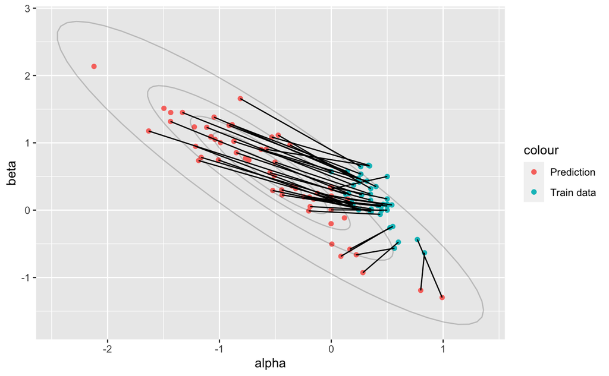

```r
q3_pic_alpha_beta
```

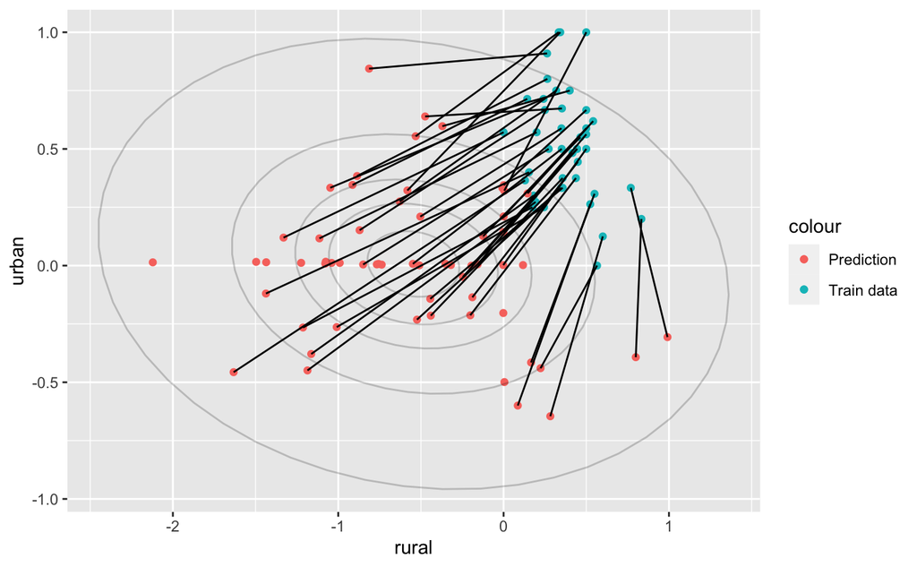

```r
q3_pic_rural_urban
```